# Calculating Walking and cycling trips impedance function- 1992

# Active-transport walking and cycling behaviour in Canada

## Data and Method

Data on walking and cycling trips to different destinations was derived from Canada’s General Social Survey (GSS) from 1986 to 2015. GSS is a social trends survey in order to monitor changes in the living conditions and well-being of Canadians and to provide information on specific social policy issues. one of the important information of GSS is about Time-use surveys. This survey collects information on all human activities and can therefore inform a broad range of policies. Statistics Canada has been conducting time-use surveys since 1986 at approximately five- to seven- year intervals, most recently in 2015.The GSS on time use employs a retrospective 24-hour time diary to collect information on respondents’ participation in, and time spent on, a wide variety of day-to-day activities. In addition, information is collected on the location where these activities occurred (e.g., at home, at work, etc.).in addition, This dataset contains travel time data of Many of the Census Metropolitan Areas (CMAs) and non-CMA areas all over Canada. CMAs are including St. John’s, Halifax, Saint John, Montreal, Quebec City, Toronto, Ottawa, Hamilton, Winnipeg, Regina, Saskatoon, Calgary, Edmonton, and Vancouver. and the non-CMA areas of each of the ten provinces were also grouped to form ten more strata.

walking and cycling data are categorized based on the three different destinations such as home, school and work, and others’ homes. every episode includes, the start and end time of each event, duration, weight, and concurrent contextual information, such as the location of the activities (e.g., home, work, schools,…).

# Result

First load all of the libraries

Here, we are loading all the primary files of the GSS dataset to create our database for analysis.

### Calculating impedance function for walking in 1992

```r
count <- sum(walking_1992$DURATION > 100)
print (count)
```

```
[1] 26
```

```r
walking_1992 <- walking_1992 %>% filter(DURATION < 100)
summary(walking_1992$DURATION)
```

```
   Min. 1st Qu.  Median    Mean 3rd Qu.    Max.
   1.00    5.00   10.00   16.83   20.00   95.00
```

using a skew vs. kurtois graph to descriptive statistics of data:

```
summary statistics
------
min:  1   max:  95
median:  10
mean:  16.83446
estimated sd:  17.43053
estimated skewness:  2.128361
estimated kurtosis:  7.616158
```

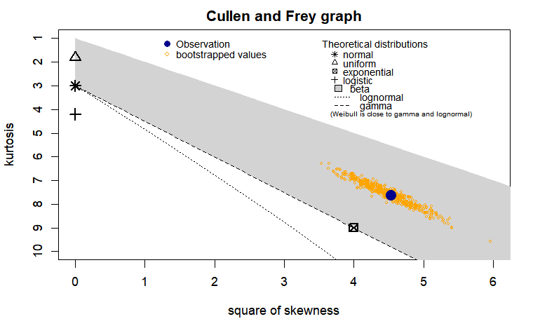

```r
# creating a skew vs. kurtois graph for walking 1992

descdist(walking_1992$DURATION %>% unlist() %>% as.numeric(), discrete=FALSE, boot=500)
```

```r
summary(walking_1992$WGHT_EPI)
```

```
   Min. 1st Qu.  Median    Mean 3rd Qu.    Max.    NA's
  128.6   947.4  1692.6  2215.3  2878.9 12187.0       3
```

```r
walking_1992$WGHT_EPI[is.na(walking_1992$WGHT_EPI)] <- 1
```

As shown in the Cullen and Frey graph, we see that gamma and exponential will likely be the best fit according to the graph above. Then we compare these models to find the best model.

```r
# Based on the skew vs. kurtois graph the best distribution

#Calculating gamma distribution

gamma_w_1992_ <- fitdistrplus::fitdist(data=walking_1992$DURATION%>% unlist() %>% as.numeric(), "gamma", method="mle", optim.method="Nelder-Mead", weights = round(walking_1992$WGHT_EPI))
fit_dgamma <- data.frame(f = dgamma(walking_1992$DURATION, shape = gamma_w_1992_$estimate[1], rate = gamma_w_1992_$estimate[2]), x = walking_1992$DURATION, type = "Gamma")

summary(gamma_w_1992_)
```

```
Fitting of the distribution ' gamma ' by maximum likelihood
Parameters :
```

|  | estimate | Std. Error |
| --- | --- | --- |
| shape | 1.41602151 | 1.005225e-03 |
| rate | 0.07743356 | 6.571886e-05 |

```
Loglikelihood:  -12618984   AIC:  25237972   BIC:  25237983
Correlation matrix:
          shape      rate
shape 1.0000000 0.8362034
rate  0.8362034 1.0000000
```

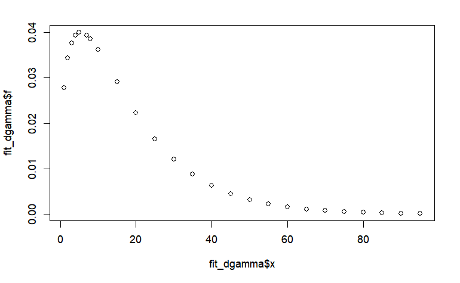

```r
plot(x= fit_dgamma$x, y=fit_dgamma$f)
```

```r
#Calculating exponential distribution
exp_w_1992_ <- fitdistrplus::fitdist(data=walking_1992$DURATION%>% unlist() %>% as.numeric(), "exp", method="mle", optim.method="Nelder-Mead", weights = round(walking_1992$WGHT_EPI))
summary(exp_w_1992_)
```

```
Fitting of the distribution ' exp ' by maximum likelihood
Parameters :
```

|  | estimate | Std. Error |
| --- | --- | --- |
| rate | 0.05471477 | 3.029984e-05 |

```
Loglikelihood:  -12728284   AIC:  25456570   BIC:  25456575
```

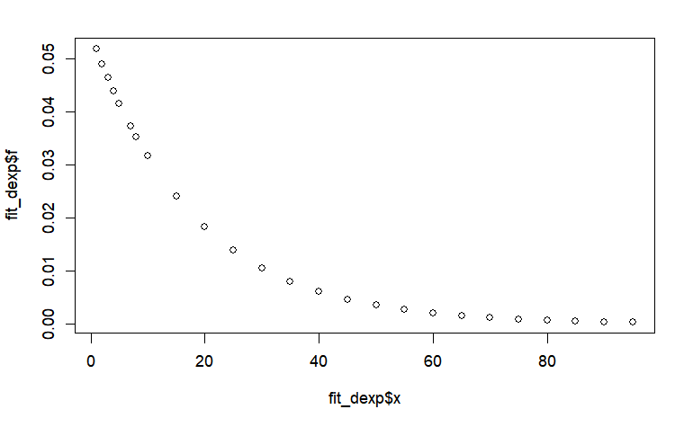

```r
# Get the estimated rate parameter from the fitted distribution
rate_estimate <- exp_w_1992_$estimate[1]

# Create a data frame for the fitted exponential distribution
fit_dexp <- data.frame(f = dexp(walking_1992$DURATION, rate = rate_estimate),
                       x = walking_1992$DURATION, type = "exp")

# Plot the fitted exponential distribution
plot(x = fit_dexp$x, y = fit_dexp$f)
```

Now let’s compare these models based on AIC and BIC to see which fits the walk data best:

```r
#comparing these models AIC and BIC to see which fits the walk data best:
broom::glance(MASS::fitdistr(walking_1992$DURATION%>% unlist() %>% as.numeric(),"gamma"))
```

| logLik | AIC | BIC | nobs |
| --- | --- | --- | --- |
| -5591.9 | 11187.8 | 11198.39 | 1474 |

```r
broom::glance(MASS::fitdistr(walking_1992$DURATION%>% unlist() %>% as.numeric(),"exponential"))
```

| logLik | AIC | BIC | nobs |
| --- | --- | --- | --- |
| -5635.733 | 11273.47 | 11278.76 | 1474 |

So, gamma has largest logLik and the smallest AIC and BIC. we will pick gamma function for walking trips in 1992!

```r
walking_1992_gamma <- gamma_w_1992_
walking_1992 <- walking_1992 %>%
 mutate(f = dgamma(DURATION, walking_1992_gamma$estimate["shape"], walking_1992_gamma$estimate["rate"]))
summary(walking_1992$f)
```

```
     Min.   1st Qu.    Median      Mean   3rd Qu.      Max.
0.0001279 0.0222687 0.0362034 0.0293172 0.0399631 0.0399631
```

### Destination : Home (1)- 1992

using a skew vs. kurtois graph to descriptive statistics of data

```
summary statistics
------
min:  1   max:  95
median:  10
mean:  19.86406
estimated sd:  19.98361
estimated skewness:  1.742374
estimated kurtosis:  5.59104
```

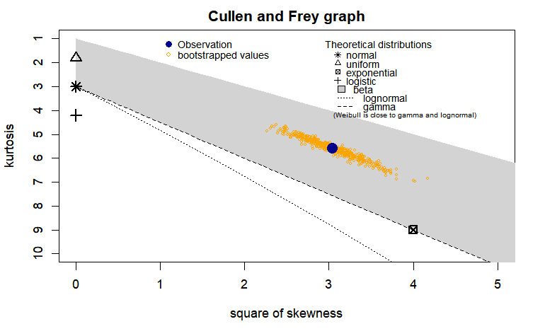

```r
# creating a skew vs. kurtois graph for walking 1992

# Filter the data based on the "destination" column
 w_1_1992 <- walking_1992 %>%
  filter(destination == "1")
descdist(w_1_1992$DURATION %>% unlist() %>% as.numeric(), discrete=FALSE, boot=500)
```

As shown in the Cullen and Frey graph, we see that gamma and exponential will likely be the best fit according to the graph above. Then we compare these models to find the best model.

```r
# Based on the skew vs. kurtois graph the best distribution

#Calculating gamma distribution
gamma_w1_1992_ <- fitdistrplus::fitdist(data=w_1_1992$DURATION%>% unlist() %>% as.numeric(), "gamma", method="mle", optim.method="Nelder-Mead", weights = round(w_1_1992$WGHT_EPI))
fit_dgamma_w192 <- data.frame(f = dgamma(w_1_1992$DURATION, shape = gamma_w1_1992_$estimate[1], rate = gamma_w1_1992_$estimate[2]), x = w_1_1992$DURATION, type = "Gamma")

summary(gamma_w1_1992_)
```

```
Fitting of the distribution ' gamma ' by maximum likelihood
Parameters :
```

|  | estimate | Std. Error |
| --- | --- | --- |
| shape | 1.3708879 | 1.257357e-03 |
| rate | 0.0619037 | 6.826151e-05 |

```
Loglikelihood:  -7902276   AIC:  15804555   BIC:  15804565
Correlation matrix:
          shape      rate
shape 1.0000000 0.8313973
rate  0.8313973 1.0000000
```

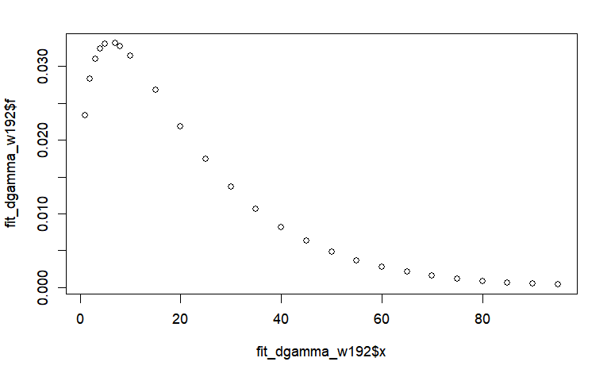

```r
plot(x= fit_dgamma_w192$x, y=fit_dgamma_w192$f)
```

```r
#Calculating exponential distribution
exp_w1_1992_ <- fitdistrplus::fitdist(data=w_1_1992$DURATION%>% unlist() %>% as.numeric(), "exp", method="mle", optim.method="Nelder-Mead", weights = round(w_1_1992$WGHT_EPI))
summary(exp_w1_1992_)
```

```
Fitting of the distribution ' exp ' by maximum likelihood
Parameters :
```

|  | estimate | Std. Error |
| --- | --- | --- |
| rate | 0.04515065 | 3.23853e-05 |

```
Loglikelihood:  -7956683   AIC:  15913368   BIC:  15913373
```

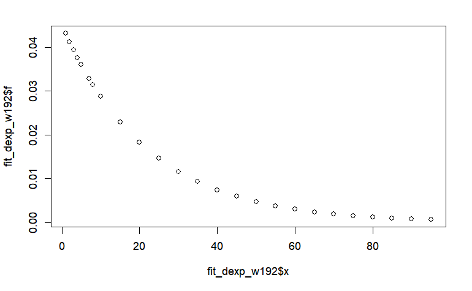

```r
fit_dexp_w192 <- data.frame(f = dexp(w_1_1992$DURATION, rate = exp_w1_1992_$estimate[1]),
                       x = w_1_1992$DURATION, type = "exp")

plot(x = fit_dexp_w192$x, y = fit_dexp_w192$f)
```

Now let’s compare these models AIC and BIC to see which fits the walk data best:

```r
#comparing these models AIC and BIC to see which fits the walk data best:
broom::glance(MASS::fitdistr(w_1_1992$DURATION%>% unlist() %>% as.numeric(),"gamma"))
```

| logLik | AIC | BIC | nobs |
| --- | --- | --- | --- |
| -3445.925 | 6895.851 | 6905.383 | 868 |

```r
broom::glance(MASS::fitdistr(w_1_1992$DURATION%>% unlist() %>% as.numeric(),"exponential"))
```

| logLik | AIC | BIC | nobs |
| --- | --- | --- | --- |
| -3462.375 | 6926.751 | 6931.517 | 868 |

So, gamma has largest logLik and the smallest AIC and BIC. we will pick gamma function for walking trips in 1992!

```r
walking_192_gamma <- gamma_w1_1992_
w_1_1992 <- w_1_1992 %>%
 mutate(f_1 = dgamma(DURATION, walking_192_gamma$estimate["shape"], walking_192_gamma$estimate["rate"]))
summary(w_1_1992$f_1)
```

```
    Min.  1st Qu.   Median     Mean  3rd Qu.     Max.
0.000375 0.013673 0.028343 0.023986 0.033066 0.033098
```

### Destination : Work place (2)- 1992

using a skew vs. kurtois graph to descriptive statistics of data

```
summary statistics
------
min:  2   max:  60
median:  10
mean:  12.77778
estimated sd:  9.827746
estimated skewness:  1.934635
estimated kurtosis:  7.397949
```

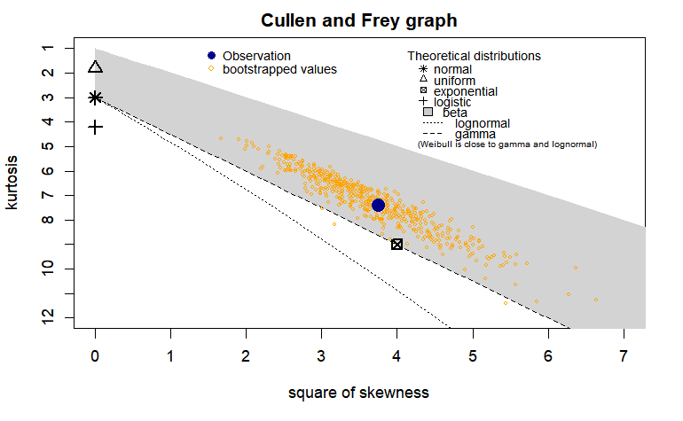

```r
# creating a skew vs. kurtois graph for walking 1992

# Filter the data based on the "destination" column
 w_2_1992 <- walking_1992 %>%
  filter(destination == "2")
descdist(w_2_1992$DURATION %>% unlist() %>% as.numeric(), discrete=FALSE, boot=500)
```

As shown in the Cullen and Frey graph, we see that gamma and exponential will likely be the best fit according to the graph above. Then we compare these models to find the best model.

```r
# Based on the skew vs. kurtois graph the best distribution

#Calculating gamma distribution
gamma_w2_1992_ <- fitdistrplus::fitdist(data=w_2_1992$DURATION%>% unlist() %>% as.numeric(), "gamma", method="mle", optim.method="Nelder-Mead", weights = round(w_2_1992$WGHT_EPI))
fit_dgamma_w292 <- data.frame(f = dgamma(w_2_1992$DURATION, shape = gamma_w2_1992_$estimate[1], rate = gamma_w2_1992_$estimate[2]), x = w_2_1992$DURATION, type = "Gamma")

summary(gamma_w2_1992_)
```

```
Fitting of the distribution ' gamma ' by maximum likelihood
Parameters :
```

|  | estimate | Std. Error |
| --- | --- | --- |
| shape | 2.4293094 | 0.0038695586 |
| rate | 0.1923618 | 0.0003402534 |

```
Loglikelihood:  -2336748   AIC:  4673500   BIC:  4673508
Correlation matrix:
         shape     rate
shape 1.000000 0.900483
rate  0.900483 1.000000
```

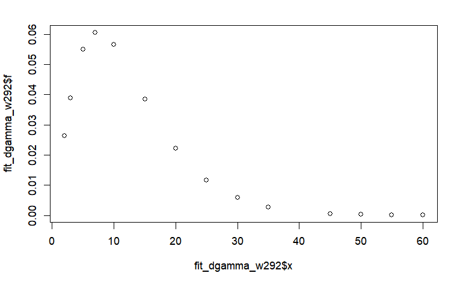

```r
plot(x= fit_dgamma_w292$x, y=fit_dgamma_w292$f)
```

```r
#Calculating exponential distribution
exp_w2_1992_ <- fitdistrplus::fitdist(data=w_2_1992$DURATION%>% unlist() %>% as.numeric(), "exp", method="mle", optim.method="Nelder-Mead", weights = round(w_2_1992$WGHT_EPI))
summary(exp_w2_1992_)
```

```
Fitting of the distribution ' exp ' by maximum likelihood
Parameters :
```

|  | estimate | Std. Error |
| --- | --- | --- |
| rate | 0.07923913 | 9.499219e-05 |

```
Loglikelihood:  -2459693   AIC:  4919388   BIC:  4919392
```

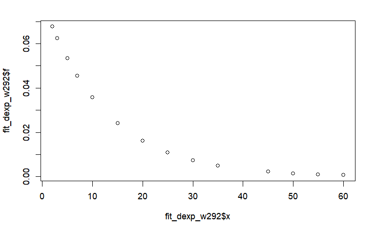

```r
fit_dexp_w292 <- data.frame(f = dexp(w_2_1992$DURATION, rate = exp_w2_1992_$estimate[1]),
                       x = w_2_1992$DURATION, type = "exp")

plot(x = fit_dexp_w292$x, y = fit_dexp_w292$f)
```

Now let’s compare these models AIC and BIC to see which fits the walk data best:

```r
#comparing these models AIC and BIC to see which fits the walk data best:
broom::glance(MASS::fitdistr(w_2_1992$DURATION%>% unlist() %>% as.numeric(),"gamma"))
```

| logLik | AIC | BIC | nobs |
| --- | --- | --- | --- |
| -976.832 | 1957.664 | 1964.99 | 288 |

```r
broom::glance(MASS::fitdistr(w_2_1992$DURATION%>% unlist() %>% as.numeric(),"exponential"))
```

| logLik | AIC | BIC | nobs |
| --- | --- | --- | --- |
| -1021.74 | 2045.48 | 2049.143 | 288 |

So, gamma has largest logLik and the smallest AIC and BIC. we will pick gamma function for walking trips in 1992!

```r
walking_292_gamma <- gamma_w2_1992_
w_2_1992 <- w_2_1992 %>%
 mutate(f_2 = dgamma(DURATION, walking_292_gamma$estimate["shape"], walking_292_gamma$estimate["rate"]))
summary(w_2_1992$f_2)
```

```
     Min.   1st Qu.    Median      Mean   3rd Qu.      Max.
4.868e-05 3.856e-02 5.491e-02 4.356e-02 5.652e-02 6.045e-02
```

### Destination : Other’s Home (3)- 1992

using a skew vs. kurtois graph to descriptive statistics of data

```
summary statistics
------
min:  1   max:  90
median:  5
mean:  12.23899
estimated sd:  13.07077
estimated skewness:  2.832249
estimated kurtosis:  12.52371
```

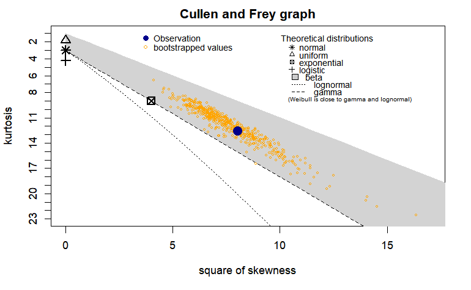

```r
# creating a skew vs. kurtois graph for walking 1992

# Filter the data based on the "destination" column
 w_3_1992 <- walking_1992 %>%
  filter(destination == "3")
descdist(w_3_1992$DURATION %>% unlist() %>% as.numeric(), discrete=FALSE, boot=500)
```

As shown in the Cullen and Frey graph, we see that gamma, weibull and exponential will likely be the best fit according to the graph above. Then we compare these models to find the best model.

```r
# Based on the skew vs. kurtois graph the best distribution

#Calculating gamma distribution
gamma_w3_1992_ <- fitdistrplus::fitdist(data=w_3_1992$DURATION%>% unlist() %>% as.numeric(), "gamma", method="mle", optim.method="Nelder-Mead", weights = round(w_3_1992$WGHT_EPI))
fit_dgamma_w392 <- data.frame(f = dgamma(w_3_1992$DURATION, shape = gamma_w3_1992_$estimate[1], rate = gamma_w3_1992_$estimate[2]), x = w_3_1992$DURATION, type = "Gamma")

summary(gamma_w3_1992_)
```

```
Fitting of the distribution ' gamma ' by maximum likelihood
Parameters :
```

|  | estimate | Std. Error |
| --- | --- | --- |
| shape | 1.5709153 | 0.0025745062 |
| rate | 0.1252232 | 0.0002411915 |

```
Loglikelihood:  -2159073   AIC:  4318151   BIC:  4318158
Correlation matrix:
          shape      rate
shape 1.0000000 0.8507811
rate  0.8507811 1.0000000
```

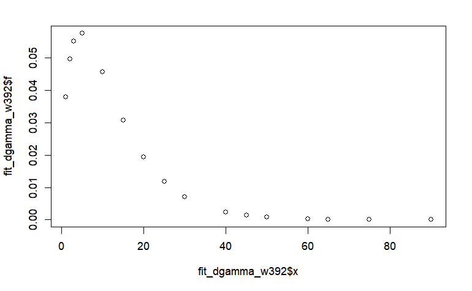

```r
plot(x= fit_dgamma_w392$x, y=fit_dgamma_w392$f)
```

```r
#Calculating weibull distribution
weibull_w3_1992_ <- fitdistrplus::fitdist(data=w_3_1992$DURATION%>% unlist() %>% as.numeric(), "weibull", method="mle", optim.method="Nelder-Mead", weights = round(w_3_1992$WGHT_EPI))
fit_dweibull_w392 <- data.frame(f = dweibull(w_3_1992$DURATION, shape = weibull_w3_1992_$estimate[1], scale = weibull_w3_1992_$estimate[2]), x = w_3_1992$DURATION, type = "weibull")

summary(weibull_w3_1992_)
```

```
Fitting of the distribution ' weibull ' by maximum likelihood
Parameters :
```

|  | estimate | Std. Error |
| --- | --- | --- |
| shape | 1.158329 | 0.001028391 |
| scale | 13.343970 | 0.015561727 |

```
Loglikelihood:  -2180163   AIC:  4360330   BIC:  4360338
Correlation matrix:
          shape     scale
shape 1.0000000 0.3432222
scale 0.3432222 1.0000000
```

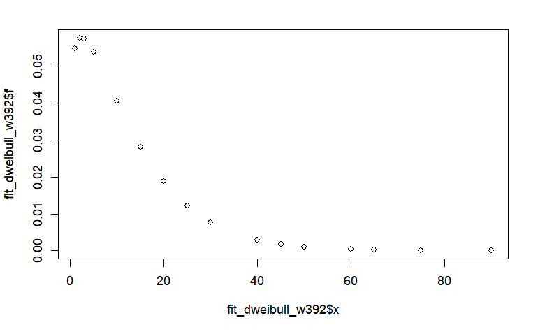

```r
plot(x= fit_dweibull_w392$x, y=fit_dweibull_w392$f)
```

```r
#Calculating exponential distribution
exp_w3_1992_ <- fitdistrplus::fitdist(data=w_3_1992$DURATION%>% unlist() %>% as.numeric(), "exp", method="mle", optim.method="Nelder-Mead", weights = round(w_3_1992$WGHT_EPI))
summary(exp_w3_1992_)
```

```
Fitting of the distribution ' exp ' by maximum likelihood
Parameters :
```

|  | estimate | Std. Error |
| --- | --- | --- |
| rate | 0.07972724 | 0.0001011368 |

```
Loglikelihood:  -2192656   AIC:  4385313   BIC:  4385317
```

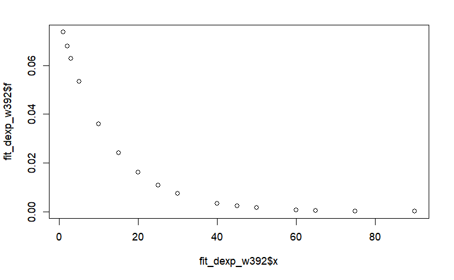

```r
fit_dexp_w392 <- data.frame(f = dexp(w_3_1992$DURATION, rate = exp_w3_1992_$estimate[1]),
                       x = w_3_1992$DURATION, type = "exp")

plot(x = fit_dexp_w392$x, y = fit_dexp_w392$f)
```

Now let’s compare these models AIC and BIC to see which fits the walk data best:

```r
#comparing these models AIC and BIC to see which fits the walk data best:
broom::glance(MASS::fitdistr(w_3_1992$DURATION%>% unlist() %>% as.numeric(),"gamma"))
```

| logLik | AIC | BIC | nobs |
| --- | --- | --- | --- |
| -1097.087 | 2198.174 | 2205.698 | 318 |

```r
broom::glance(MASS::fitdistr(w_3_1992$DURATION%>% unlist() %>% as.numeric(),"weibull"))
```

| logLik | AIC | BIC | nobs |
| --- | --- | --- | --- |
| -1108.027 | 2220.055 | 2227.579 | 318 |

```r
broom::glance(MASS::fitdistr(w_3_1992$DURATION%>% unlist() %>% as.numeric(),"exponential"))
```

| logLik | AIC | BIC | nobs |
| --- | --- | --- | --- |
| -1114.471 | 2230.943 | 2234.705 | 318 |

```r
walking_392_gamma <- gamma_w3_1992_
w_3_1992 <- w_3_1992 %>%
 mutate(f_3 = dgamma(DURATION, walking_392_gamma$estimate["shape"], walking_392_gamma$estimate["rate"]))
summary(w_3_1992$f_3)
```

```
     Min.   1st Qu.    Median      Mean   3rd Qu.      Max.
7.150e-06 3.080e-02 5.638e-02 4.331e-02 5.754e-02 5.754e-02
```

### Calculating impedance function for cycling in 1992

```r
count <- sum(cycling_1992$DURATION > 100)
print (count)
```

```
[1] 9
```

```r
cycling_1992 <- cycling_1992 %>% filter(DURATION < 100)
summary(cycling_1992$DURATION)
```

```
   Min. 1st Qu.  Median    Mean 3rd Qu.    Max.
   5.00   10.00   15.00   23.57   30.00   90.00
```

using a skew vs. kurtois graph to descriptive statistics of data:

```
summary statistics
------
min:  5   max:  90
median:  15
mean:  23.57143
estimated sd:  20.59958
estimated skewness:  1.582969
estimated kurtosis:  5.320847
```

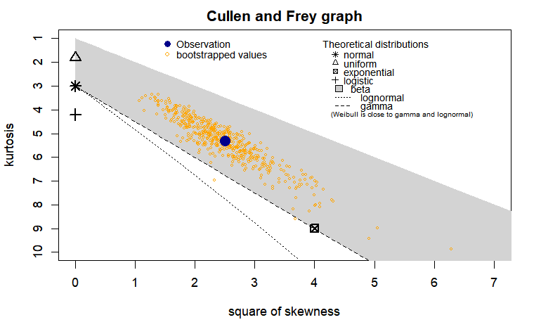

```r
# creating a skew vs. kurtois graph for cycling 1992

descdist(cycling_1992$DURATION %>% unlist() %>% as.numeric(), discrete=FALSE, boot=500)
```

As shown in the Cullen and Frey graph, we see that gamma and exponential will likely be the best fit according to the graph above. Then we compare these models to find the best model.

```r
summary(cycling_1992$DURATION)
```

```
   Min. 1st Qu.  Median    Mean 3rd Qu.    Max.
   5.00   10.00   15.00   23.57   30.00   90.00
```

```r
# Based on the skew vs. kurtois graph the best distribution

#Calculating gamma distribution

gamma_c_1992_ <- fitdistrplus::fitdist(data=cycling_1992$DURATION%>% unlist() %>% as.numeric(), "gamma", method="mle", optim.method="Nelder-Mead", weights = round(cycling_1992$WGHT_EPI))
fit_dgamma <- data.frame(f = dgamma(cycling_1992$DURATION, shape = gamma_c_1992_$estimate[1], rate = gamma_c_1992_$estimate[2]), x = cycling_1992$DURATION, type = "gamma")

summary(gamma_c_1992_)
```

```
Fitting of the distribution ' gamma ' by maximum likelihood
Parameters :
```

|  | estimate | Std. Error |
| --- | --- | --- |
| shape | 1.45637725 | 0.0032151264 |
| rate | 0.06770605 | 0.0001778298 |

```
Loglikelihood:  -1363541   AIC:  2727086   BIC:  2727091
Correlation matrix:
          shape      rate
shape 1.0000000 0.8402124
rate  0.8402124 1.0000000
```

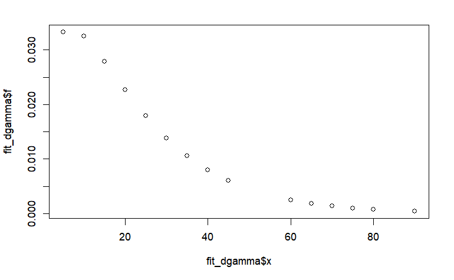

```r
plot(x= fit_dgamma$x, y=fit_dgamma$f)
```

```r
#Calculating exponential distribution
exp_c_1992_ <- fitdistrplus::fitdist(data=cycling_1992$DURATION%>% unlist() %>% as.numeric(), "exp", method="mle", optim.method="Nelder-Mead", weights = round(cycling_1992$WGHT_EPI))
summary(exp_c_1992_)
```

```
Fitting of the distribution ' exp ' by maximum likelihood
Parameters :
```

|  | estimate | Std. Error |
| --- | --- | --- |
| rate | 0.0464678 | 7.984821e-05 |

```
Loglikelihood:  -1376641   AIC:  2753284   BIC:  2753287
```

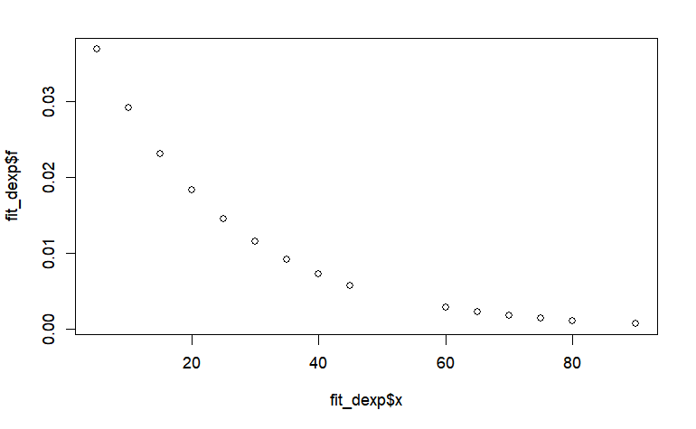

```r
fit_dexp <- data.frame(f = dexp(cycling_1992$DURATION, rate = exp_c_1992_$estimate[1]), x = cycling_1992$DURATION, type = "exp")

plot(x= fit_dexp$x, y=fit_dexp$f)
```

Now let’s compare these models based on AIC and BIC to see which fits the walk data best:

```r
#comparing these models AIC and BIC to see which fits the walk data best:
broom::glance(MASS::fitdistr(cycling_1992$DURATION%>% unlist() %>% as.numeric(),"gamma"))
```

| logLik | AIC | BIC | nobs |
| --- | --- | --- | --- |
| -517.8119 | 1039.624 | 1045.296 | 126 |

```r
broom::glance(MASS::fitdistr(cycling_1992$DURATION%>% unlist() %>% as.numeric(),"exponential"))
```

| logLik | AIC | BIC | nobs |
| --- | --- | --- | --- |
| -524.1645 | 1050.329 | 1053.165 | 126 |

So, gamma has largest logLik and the smallest AIC and BIC. we will pick gamma function for cycling trips in 1992!

```r
cycling_1992_gamma <- gamma_c_1992_
cycling_1992 <- cycling_1992 %>%
 mutate(f = dgamma(DURATION, cycling_1992_gamma$estimate["shape"] , cycling_1992_gamma$estimate["rate"]))
summary(cycling_1992$f)
```

```
     Min.   1st Qu.    Median      Mean   3rd Qu.      Max.
0.0003937 0.0138580 0.0278858 0.0220492 0.0325118 0.0332414
```

### Destination : Cycling - Home (1), 1992

using a skew vs. kurtois graph to descriptive statistics of data

```
summary statistics
------
min:  5   max:  90
median:  20
mean:  28.18841
estimated sd:  24.17721
estimated skewness:  1.221192
estimated kurtosis:  3.721866
```

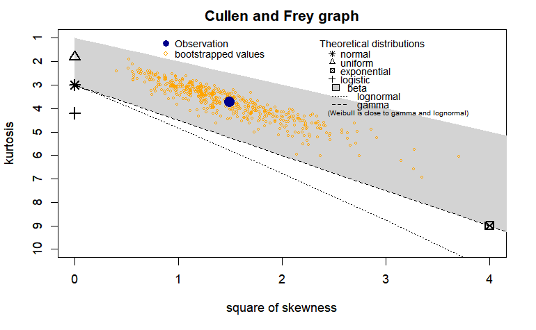

```r
# creating a skew vs. kurtois graph for cycling 1992

# Filter the data based on the "destination" column
 c_1_1992 <- cycling_1992 %>%
  filter(destination == "1")
descdist(c_1_1992$DURATION %>% unlist() %>% as.numeric(), discrete=FALSE, boot=500)
```

As shown in the Cullen and Frey graph, we see that gamma, weibull and exponential will likely be the best fit according to the graph above. Then we compare these models to find the best model.

```r
# Based on the skew vs. kurtois graph the best distribution

#Calculating gamma distribution
gamma_c1_1992_ <- fitdistrplus::fitdist(data=c_1_1992$DURATION%>% unlist() %>% as.numeric(), "gamma", method="mle", optim.method="Nelder-Mead", weights = round(c_1_1992$WGHT_EPI))
fit_dgamma_c192 <- data.frame(f = dgamma(c_1_1992$DURATION, shape = gamma_c1_1992_$estimate[1], rate = gamma_c1_1992_$estimate[2]), x = c_1_1992$DURATION, type = "Gamma")

summary(gamma_c1_1992_)
```

```
Fitting of the distribution ' gamma ' by maximum likelihood
Parameters :
```

|  | estimate | Std. Error |
| --- | --- | --- |
| shape | 1.28738850 | 0.0038241396 |
| rate | 0.05093507 | 0.0001839901 |

```
Loglikelihood:  -771695.1   AIC:  1543394   BIC:  1543399
Correlation matrix:
          shape      rate
shape 1.0000000 0.8218022
rate  0.8218022 1.0000000
```

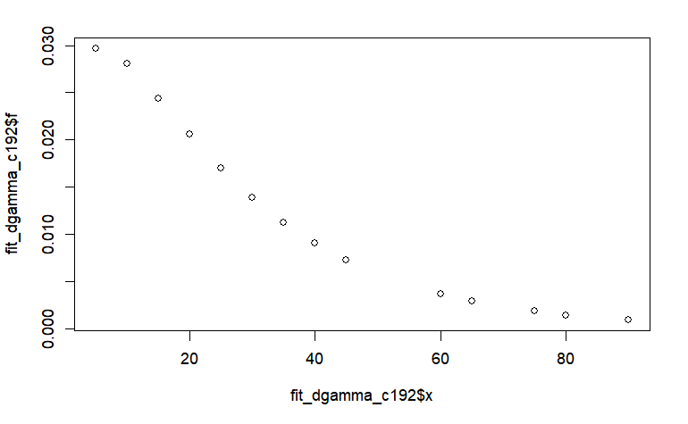

```r
plot(x= fit_dgamma_c192$x, y=fit_dgamma_c192$f)
```

```r
#Calculating weibull distribution
weibull_c1_1992_ <- fitdistrplus::fitdist(data=c_1_1992$DURATION%>% unlist() %>% as.numeric(), "weibull", method="mle", optim.method="Nelder-Mead", weights = round(c_1_1992$WGHT_EPI))
fit_dweibull_c192 <- data.frame(f = dweibull(c_1_1992$DURATION, shape = weibull_c1_1992_$estimate[1], scale = weibull_c1_1992_$estimate[2]), x = c_1_1992$DURATION, type = "weibull")

summary(weibull_c1_1992_)
```

```
Fitting of the distribution ' weibull ' by maximum likelihood
Parameters :
```

|  | estimate | Std. Error |
| --- | --- | --- |
| shape | 1.12020 | 0.001997221 |
| scale | 26.44486 | 0.058456936 |

```
Loglikelihood:  -773143.4   AIC:  1546291   BIC:  1546295
Correlation matrix:
          shape     scale
shape 1.0000000 0.3317915
scale 0.3317915 1.0000000
```

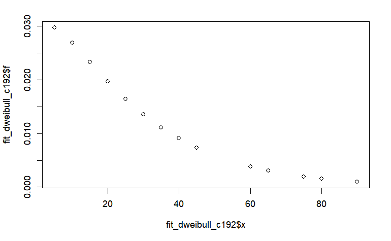

```r
plot(x= fit_dweibull_c192$x, y=fit_dweibull_c192$f)
```

```r
#Calculating exponential distribution
exp_c1_1992_ <- fitdistrplus::fitdist(data=c_1_1992$DURATION%>% unlist() %>% as.numeric(), "exp", method="mle", optim.method="Nelder-Mead", weights = round(c_1_1992$WGHT_EPI))
summary(exp_c1_1992_)
```

```
Fitting of the distribution ' exp ' by maximum likelihood
Parameters :
```

|  | estimate | Std. Error |
| --- | --- | --- |
| rate | 0.03956358 | 9.236759e-05 |

```
Loglikelihood:  -775057.5   AIC:  1550117   BIC:  1550119
```

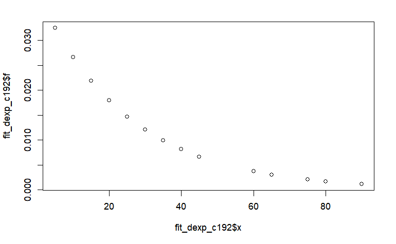

```r
fit_dexp_c192 <- data.frame(f = dexp(c_1_1992$DURATION, rate = exp_c1_1992_$estimate[1]),
                       x = c_1_1992$DURATION, type = "exp")

plot(x = fit_dexp_c192$x, y = fit_dexp_c192$f)
```

Now let’s compare these models AIC and BIC to see which fits the walk data best:

```r
#comparing these models AIC and BIC to see which fits the walk data best:
broom::glance(MASS::fitdistr(c_1_1992$DURATION%>% unlist() %>% as.numeric(),"gamma"))
```

| logLik | AIC | BIC | nobs |
| --- | --- | --- | --- |
| -296.8031 | 597.6061 | 602.0743 | 69 |

```r
broom::glance(MASS::fitdistr(c_1_1992$DURATION%>% unlist() %>% as.numeric(),"weibull"))
```

| logLik | AIC | BIC | nobs |
| --- | --- | --- | --- |
| -297.3595 | 598.719 | 603.1873 | 69 |

```r
broom::glance(MASS::fitdistr(c_1_1992$DURATION%>% unlist() %>% as.numeric(),"exponential"))
```

| logLik | AIC | BIC | nobs |
| --- | --- | --- | --- |
| -299.3848 | 600.7697 | 603.0038 | 69 |

So, gamma has largest logLik and the smallest AIC and BIC. we will pick gamma function for cycling trips in 1992!

```r
cycling_192_gamma <- gamma_c1_1992_
c_1_1992 <- c_1_1992 %>%
 mutate(f_1 = dgamma(DURATION, cycling_192_gamma$estimate["shape"], cycling_192_gamma$estimate["rate"]))
summary(c_1_1992$f_1)
```

```
     Min.   1st Qu.    Median      Mean   3rd Qu.      Max.
0.0008958 0.0090578 0.0205554 0.0182408 0.0280300 0.0296288
```

### Destination :cycling- Work place (2), 1992

using a skew vs. kurtois graph to descriptive statistics of data

```
summary statistics
------
min:  5   max:  45
median:  15
mean:  19.14286
estimated sd:  11.47156
estimated skewness:  0.7186285
estimated kurtosis:  2.820435
```

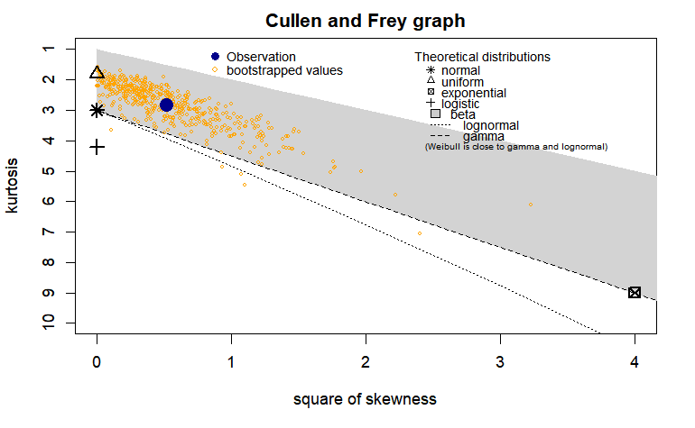

```r
# creating a skew vs. kurtois graph for cycling 1992

# Filter the data based on the "destination" column
 c_2_1992 <- cycling_1992 %>%
  filter(destination == "2")
descdist(c_2_1992$DURATION %>% unlist() %>% as.numeric(), discrete=FALSE, boot=500)
```

As shown in the Cullen and Frey graph, we see that gamma ,weibull, normal and exponential will likely be the best fit according to the graph above. Then we compare these models to find the best model.

```r
# Based on the skew vs. kurtois graph the best distribution

#Calculating gamma distribution
gamma_c2_1992_ <- fitdistrplus::fitdist(data=c_2_1992$DURATION%>% unlist() %>% as.numeric(), "gamma", method="mle", optim.method="Nelder-Mead", weights = round(c_2_1992$WGHT_EPI))
fit_dgamma_c292 <- data.frame(f = dgamma(c_2_1992$DURATION, shape = gamma_c2_1992_$estimate[1], rate = gamma_c2_1992_$estimate[2]), x = c_2_1992$DURATION, type = "Gamma")

summary(gamma_c2_1992_)
```

```
Fitting of the distribution ' gamma ' by maximum likelihood
Parameters :
```

|  | estimate | Std. Error |
| --- | --- | --- |
| shape | 2.9170970 | 0.0131576157 |
| rate | 0.1652082 | 0.0008130514 |

```
Loglikelihood:  -320916.5   AIC:  641837.1   BIC:  641840.2
Correlation matrix:
          shape      rate
shape 1.0000000 0.9164595
rate  0.9164595 1.0000000
```

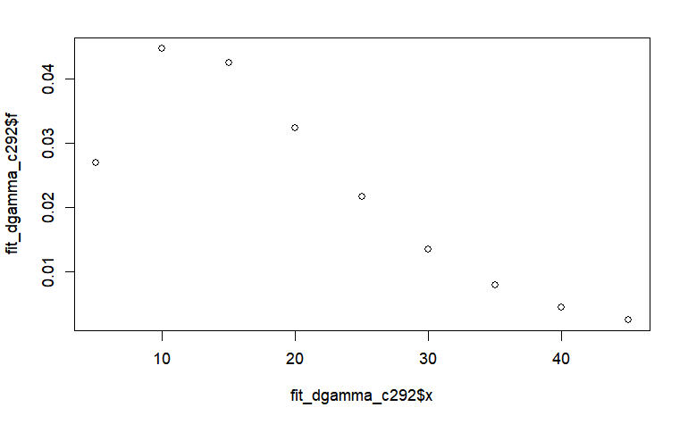

```r
plot(x= fit_dgamma_c292$x, y=fit_dgamma_c292$f)
```

```r
#Calculating weibull distribution
weibull_c2_1992_ <- fitdistrplus::fitdist(data=c_2_1992$DURATION%>% unlist() %>% as.numeric(), "weibull", method="mle", optim.method="Nelder-Mead", weights = round(c_2_1992$WGHT_EPI))
fit_dweibull_c292 <- data.frame(f = dweibull(c_2_1992$DURATION, shape = weibull_c2_1992_$estimate[1], scale = weibull_c2_1992_$estimate[2]), x = c_2_1992$DURATION, type = "weibull")

summary(weibull_c2_1992_)
```

```
Fitting of the distribution ' weibull ' by maximum likelihood
Parameters :
```

|  | estimate | Std. Error |
| --- | --- | --- |
| shape | 1.836474 | 0.004751274 |
| scale | 19.950734 | 0.038607161 |

```
Loglikelihood:  -321663.3   AIC:  643330.6   BIC:  643333.7
Correlation matrix:
          shape     scale
shape 1.0000000 0.3223991
scale 0.3223991 1.0000000
```

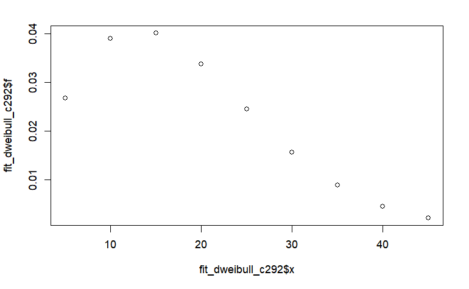

```r
plot(x= fit_dweibull_c292$x, y=fit_dweibull_c292$f)
```

```r
#Calculating normal distribution
norm_c2_1992_ <- fitdistrplus::fitdist(data=c_2_1992$DURATION%>% unlist() %>% as.numeric(), "norm", method="mle", optim.method="Nelder-Mead", weights = round(c_2_1992$WGHT_EPI))
fit_dnorm_c292 <- data.frame(f = dnorm(c_2_1992$DURATION, mean = norm_c2_1992_$estimate[1], sd = norm_c2_1992_$estimate[2]), x = c_2_1992$DURATION, type = "norm")

summary(norm_c2_1992_)
```

```
Fitting of the distribution ' norm ' by maximum likelihood
Parameters :
```

|  | estimate | Std. Error |
| --- | --- | --- |
| mean | 17.65643 | 0.03418571 |
| sd | 10.16408 | 0.02417723 |

```
Loglikelihood:  -330407.2   AIC:  660818.4   BIC:  660821.5
Correlation matrix:
              mean            sd
mean  1.000000e+00 -7.764881e-05
sd   -7.764881e-05  1.000000e+00
```

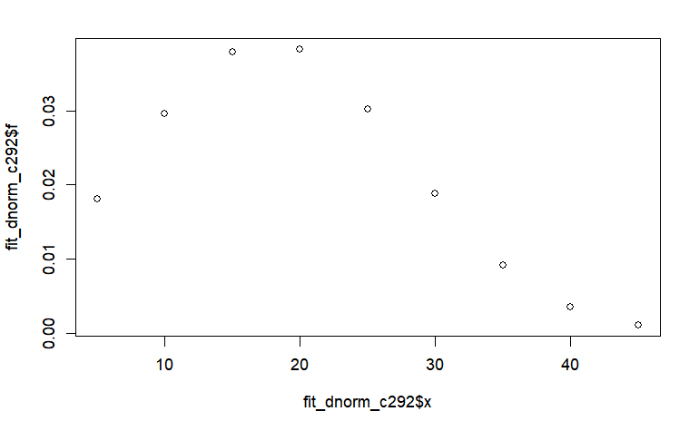

```r
plot(x= fit_dnorm_c292$x, y=fit_dnorm_c292$f)
```

```r
#Calculating exponential distribution
exp_c2_1992_ <- fitdistrplus::fitdist(data=c_2_1992$DURATION%>% unlist() %>% as.numeric(), "exp", method="mle", optim.method="Nelder-Mead", weights = round(c_2_1992$WGHT_EPI))
summary(exp_c2_1992_)
```

```
Fitting of the distribution ' exp ' by maximum likelihood
Parameters :
```

|  | estimate | Std. Error |
| --- | --- | --- |
| rate | 0.05662605 | 0.0001903957 |

```
Loglikelihood:  -342204.2   AIC:  684410.3   BIC:  684411.9
```

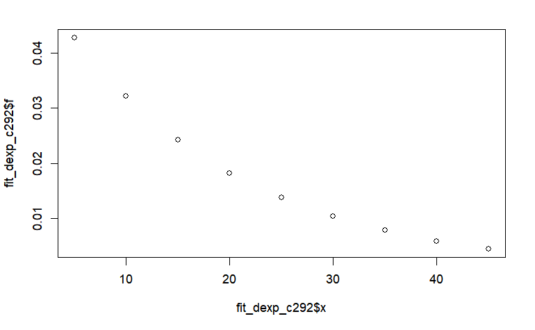

```r
fit_dexp_c292 <- data.frame(f = dexp(c_2_1992$DURATION, rate = exp_c2_1992_$estimate[1]),
                       x = c_2_1992$DURATION, type = "exp")

plot(x = fit_dexp_c292$x, y = fit_dexp_c292$f)
```

Now let’s compare these models AIC and BIC to see which fits the walk data best:

```r
#comparing these models AIC and BIC to see which fits the walk data best:
broom::glance(MASS::fitdistr(c_2_1992$DURATION%>% unlist() %>% as.numeric(),"gamma"))
```

| logLik | AIC | BIC | nobs |
| --- | --- | --- | --- |
| -130.9781 | 265.9562 | 269.0669 | 35 |

```r
broom::glance(MASS::fitdistr(c_2_1992$DURATION%>% unlist() %>% as.numeric(),"normal"))
```

| logLik | AIC | BIC | nobs |
| --- | --- | --- | --- |
| -134.551 | 273.1021 | 276.2128 | 35 |

```r
broom::glance(MASS::fitdistr(c_2_1992$DURATION%>% unlist() %>% as.numeric(),"weibull"))
```

| logLik | AIC | BIC | nobs |
| --- | --- | --- | --- |
| -131.0569 | 266.1138 | 269.2245 | 35 |

```r
broom::glance(MASS::fitdistr(c_2_1992$DURATION%>% unlist() %>% as.numeric(),"exponential"))
```

| logLik | AIC | BIC | nobs |
| --- | --- | --- | --- |
| -138.3175 | 278.6351 | 280.1904 | 35 |

So, gamma has largest logLik and the smallest AIC and BIC. we will pick gamma function for cycling trips in 1992!

```r
cycling_292_gamma <- gamma_c2_1992_
c_2_1992 <- c_2_1992 %>%
 mutate(f_2 = dgamma(DURATION, cycling_292_gamma$estimate["shape"], cycling_292_gamma$estimate["rate"]))
summary(c_2_1992$f_2)
```

```
    Min.  1st Qu.   Median     Mean  3rd Qu.     Max.
0.002461 0.021716 0.032340 0.028811 0.042557 0.044681
```

using a skew vs. kurtois graph to descriptive statistics of data

```
summary statistics
------
min:  5   max:  70
median:  10
mean:  16.13636
estimated sd:  16.1047
estimated skewness:  2.050684
estimated kurtosis:  8.012695
```

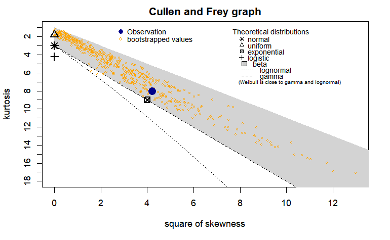

```r
# creating a skew vs. kurtois graph for cycling 1992

# Filter the data based on the "destination" column
c_3_1992 <- cycling_1992 %>%
  filter(destination == "3")
descdist(c_3_1992$DURATION %>% unlist() %>% as.numeric(), discrete=FALSE, boot=500)
```

As shown in the Cullen and Frey graph, we see that gamma, normal, lognormal and exponential will likely be the best fit according to the graph above. Then we compare these models to find the best model.

```r
# Based on the skew vs. kurtois graph the best distribution

#Calculating gamma distribution
gamma_c3_1992_ <- fitdistrplus::fitdist(data=c_3_1992$DURATION%>% unlist() %>% as.numeric(), "gamma", method="mle", optim.method="Nelder-Mead", weights = round(c_3_1992$WGHT_EPI))
fit_dgamma_c392 <- data.frame(f = dgamma(c_3_1992$DURATION, shape = gamma_c3_1992_$estimate[1], rate = gamma_c3_1992_$estimate[2]), x = c_3_1992$DURATION, type = "Gamma")

summary(gamma_c3_1992_)
```

```
Fitting of the distribution ' gamma ' by maximum likelihood
Parameters :
```

|  | estimate | Std. Error |
| --- | --- | --- |
| shape | 1.40403494 | 0.0069611806 |
| rate | 0.08625452 | 0.0005120487 |

```
Loglikelihood:  -250737.4   AIC:  501478.8   BIC:  501481
Correlation matrix:
          shape      rate
shape 1.0000000 0.8349842
rate  0.8349842 1.0000000
```

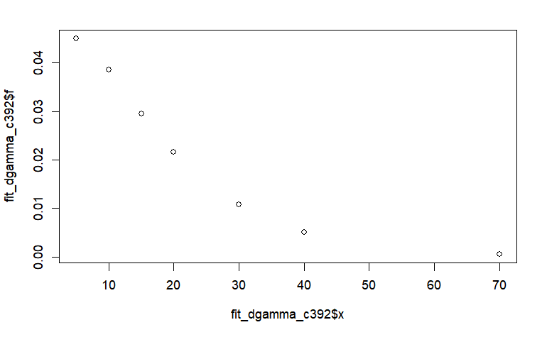

```r
plot(x= fit_dgamma_c392$x, y=fit_dgamma_c392$f)
```

```r
#Calculating normal distribution
norm_c3_1992_ <- fitdistrplus::fitdist(data=c_3_1992$DURATION%>% unlist() %>% as.numeric(), "norm", method="mle", optim.method="Nelder-Mead", weights = round(c_3_1992$WGHT_EPI))
fit_dnorm_c392 <- data.frame(f = dnorm(c_3_1992$DURATION, mean = norm_c3_1992_$estimate[1], sd = norm_c3_1992_$estimate[2]), x = c_3_1992$DURATION, type = "norm")

summary(norm_c3_1992_)
```

```
Fitting of the distribution ' norm ' by maximum likelihood
Parameters :
```

|  | estimate | Std. Error |
| --- | --- | --- |
| mean | 16.27771 | 0.06411816 |
| sd | 16.56248 | 0.04533070 |

```
Loglikelihood:  -281992.6   AIC:  563989.2   BIC:  563991.4
Correlation matrix:
              mean            sd
mean  1.000000e+00 -5.735263e-05
sd   -5.735263e-05  1.000000e+00
```

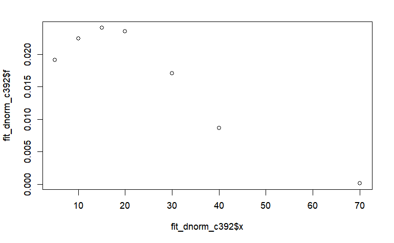

```r
plot(x= fit_dnorm_c392$x, y=fit_dnorm_c392$f)
```

```r
#Calculating lognormal distribution
lnorm_c3_1992_ <- fitdistrplus::fitdist(data=c_3_1992$DURATION%>% unlist() %>% as.numeric(), "lnorm", method="mle", optim.method="Nelder-Mead", weights = round(c_3_1992$WGHT_EPI))
fit_dlnorm_c392 <- data.frame(f = dlnorm(c_3_1992$DURATION, meanlog = lnorm_c3_1992_$estimate[1], sdlog = lnorm_c3_1992_$estimate[2]), x = c_3_1992$DURATION, type = "lnorm")

summary(lnorm_c3_1992_)
```

```
Fitting of the distribution ' lnorm ' by maximum likelihood
Parameters :
```

|  | estimate | Std. Error |
| --- | --- | --- |
| meanlog | 2.3932491 | 0.003312199 |
| sdlog | 0.8555802 | 0.002342539 |

```
Loglikelihood:  -243955.7   AIC:  487915.4   BIC:  487917.6
Correlation matrix:
              meanlog         sdlog
meanlog  1.000000e+00 -9.793118e-05
sdlog   -9.793118e-05  1.000000e+00
```

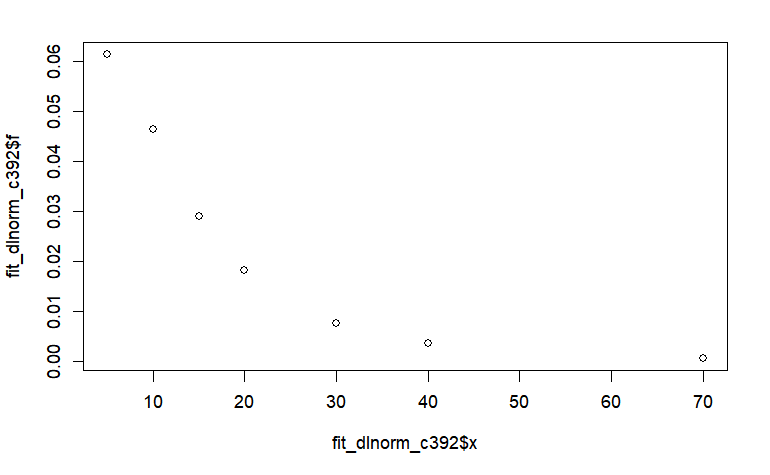

```r
plot(x= fit_dlnorm_c392$x, y=fit_dlnorm_c392$f)
```

```r
#Calculating exponential distribution
exp_c3_1992_ <- fitdistrplus::fitdist(data=c_3_1992$DURATION%>% unlist() %>% as.numeric(), "exp", method="mle", optim.method="Nelder-Mead", weights = round(c_3_1992$WGHT_EPI))
summary(exp_c3_1992_)
```

```
Fitting of the distribution ' exp ' by maximum likelihood
Parameters :
```

|  | estimate | Std. Error |
| --- | --- | --- |
| rate | 0.06143926 | 0.0002377862 |

```
Loglikelihood:  -252876.9   AIC:  505755.9   BIC:  505757
```

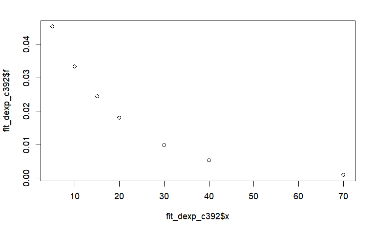

```r
fit_dexp_c392 <- data.frame(f = dexp(c_3_1992$DURATION, rate = exp_c3_1992_$estimate[1]),
                       x = c_3_1992$DURATION, type = "exp")

plot(x = fit_dexp_c392$x, y = fit_dexp_c392$f)
```

Now let’s compare these models AIC and BIC to see which fits the walk data best:

```r
#comparing these models AIC and BIC to see which fits the walk data best:
broom::glance(MASS::fitdistr(c_3_1992$DURATION%>% unlist() %>% as.numeric(),"gamma"))
```

| logLik | AIC | BIC | nobs |
| --- | --- | --- | --- |
| -82.31443 | 168.6289 | 170.811 | 22 |

```r
broom::glance(MASS::fitdistr(c_3_1992$DURATION%>% unlist() %>% as.numeric(),"normal"))
```

| logLik | AIC | BIC | nobs |
| --- | --- | --- | --- |
| -91.84538 | 187.6908 | 189.8728 | 22 |

```r
broom::glance(MASS::fitdistr(c_3_1992$DURATION%>% unlist() %>% as.numeric(),"lognormal"))
```

| logLik | AIC | BIC | nobs |
| --- | --- | --- | --- |
| -80.21923 | 164.4385 | 166.6205 | 22 |

```r
broom::glance(MASS::fitdistr(c_3_1992$DURATION%>% unlist() %>% as.numeric(),"exponential"))
```

| logLik | AIC | BIC | nobs |
| --- | --- | --- | --- |
| -83.18366 | 168.3673 | 169.4584 | 22 |

So, lognormal has largest logLik and the smallest AIC and BIC. we will pick lognormal function for cycling trips in 1992!

```r
cycling_392_lnorm <- lnorm_c3_1992_
c_3_1992 <- c_3_1992 %>%
 mutate(f_3 = dlnorm(DURATION, cycling_392_lnorm$estimate["meanlog"], cycling_392_lnorm$estimate["sdlog"]))
summary(c_3_1992$f_3)
```

```
     Min.   1st Qu.    Median      Mean   3rd Qu.      Max.
0.0006346 0.0181946 0.0463672 0.0392424 0.0612963 0.0612963
```

creating a new walking data frame that have all the f values for walking 1992

```r
walking_1992_f <- bind_rows(w_1_1992, w_2_1992, w_3_1992)
```

creating a new cycling data frame that have all the f values for cycling 1992

```r
cycling_1992_f <- bind_rows(c_1_1992, c_2_1992, c_3_1992)
```